# Assignment 1

### Task 2: Choose a non-normal probability distribution. Illustrate how CLT holds true as sample size increases by simulating repeatedly from this distribution of your choosing. Make sure to report the following.

#### a: State the exact distribution (including the exact parameter values) that you have chosen and plot its probability distribution

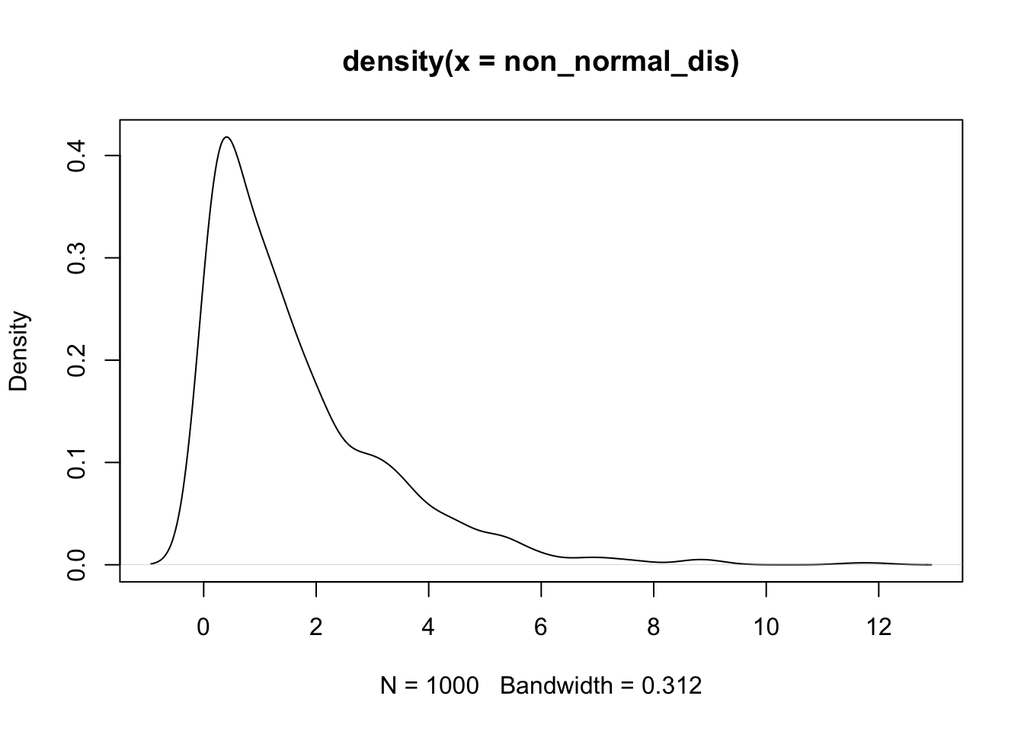

```r
# Generate a dataset of 1000 numbers following an exponential distribution with rate parameter 0.6
num_samples <- 1000
non_normal_dis <- rexp(num_samples, rate = 0.6)

# Plot the density of the exponential distribution
plot(density(non_normal_dis))
```

#### b: State the expected value (i.e. population mean) of this probability distribution.

```r
# Summary of the exponential distribution
summary(non_normal_dis)
```

```
##      Min.   1st Qu.    Median      Mean   3rd Qu.      Max.
##  0.002377  0.427174  1.138390  1.628078  2.276498 11.999134
```

```r
# Standard deviation of the exponential distribution
sd(non_normal_dis)
```

```
## [1] 1.616059
```

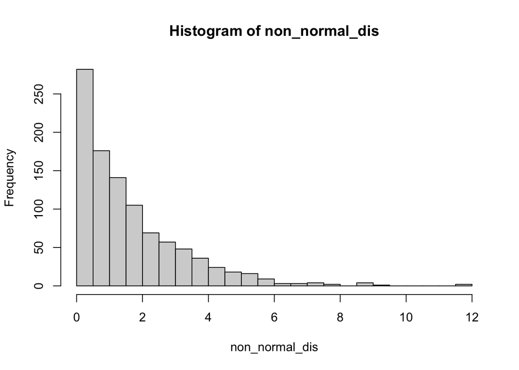

```r
# Histogram of the exponential distribution with 30 bins
hist(non_normal_dis, breaks = 30)
```

#### c: Use histogram and the summary statistic to illustrate that CLT works. Make sure that you clearly label each output so that we know exactly what you are reporting. Accompany a brief but clear explanation as to why you think that your output illustrates that the CLT works.

```r
#Sample Size == 50(LARGE)

# Array for sample means
sm_high <- c()
#In next 1000 time each sample number will generate 50 sample number means
for( i in 1:1000) {
    sm_high <- append(sm_high, mean(sample(non_normal_dis,50)))
    }
#Summarlize  sm1
sum_sm_high <-summary(sm_high)
sum_sm_high
```

```
##    Min. 1st Qu.  Median    Mean 3rd Qu.    Max.
##   1.037   1.458   1.627   1.632   1.798   2.398
```

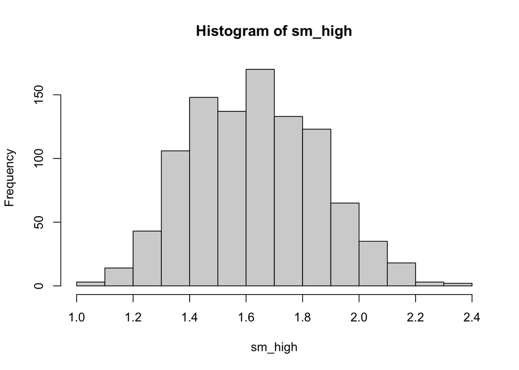

```r
#generate a histgram for sm1
hist(sm_high)
```

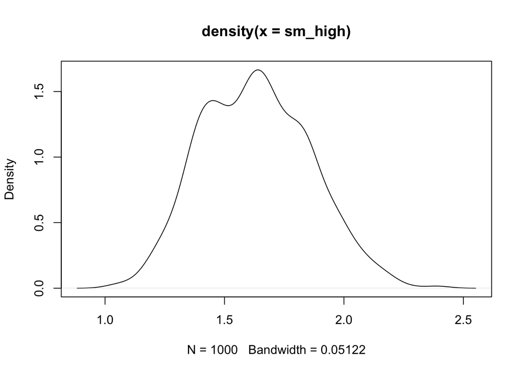

```r
#Plotting
plot(density(sm_high))
```

```r
#Sample Size == 4 (SMALL)

# Array for sample means
sm_low <- c()

#In next 1000 times, each sample number will generate 4 sample number means
for(i in 1:1000) {
    # Appending each mean of non_normal_dis to sm list
    sm_low <- append(sm_low, mean(sample(non_normal_dis, 4)))
}

# Summarize sm
sum_sm_low <- summary(sm_low)
sum_sm_low
```

```
##    Min. 1st Qu.  Median    Mean 3rd Qu.    Max.
##  0.1582  1.0034  1.5142  1.6181  2.0468  5.5424
```

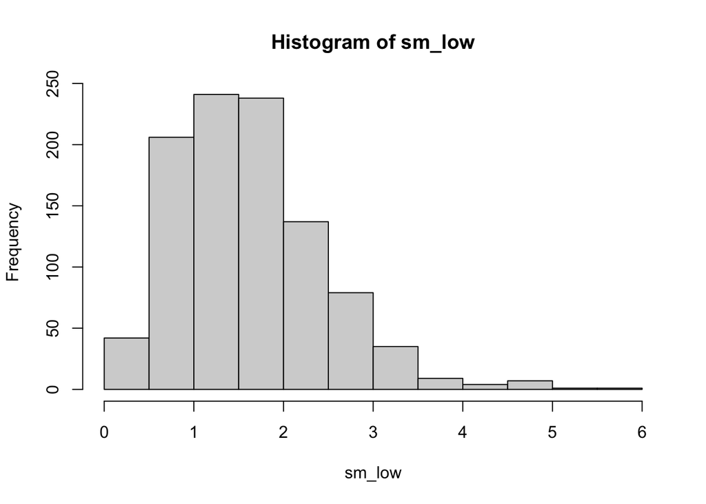

```r
#generate a histgram for sm1
hist(sm_low)
```

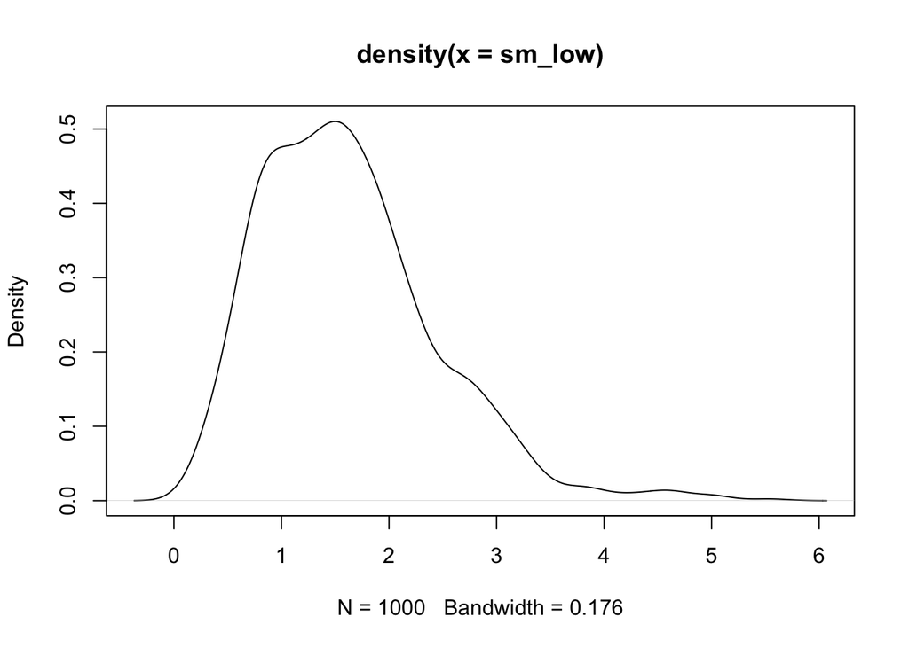

```r
#Plotting
plot(density(sm_low))
```

```r
# Combine the summaries
combined_summary <- rbind(sum_sm_high, sum_sm_low)
rownames(combined_summary) <- c("Summary of sm_high", "Summary of sm_low")
print(combined_summary)
```

```
##                         Min.  1st Qu.   Median    Mean  3rd Qu.     Max.
## Summary of sm_high 1.0372710 1.458018 1.626740 1.63219 1.798303 2.397793
## Summary of sm_low  0.1582392 1.003411 1.514241 1.61806 2.046825 5.542400
```

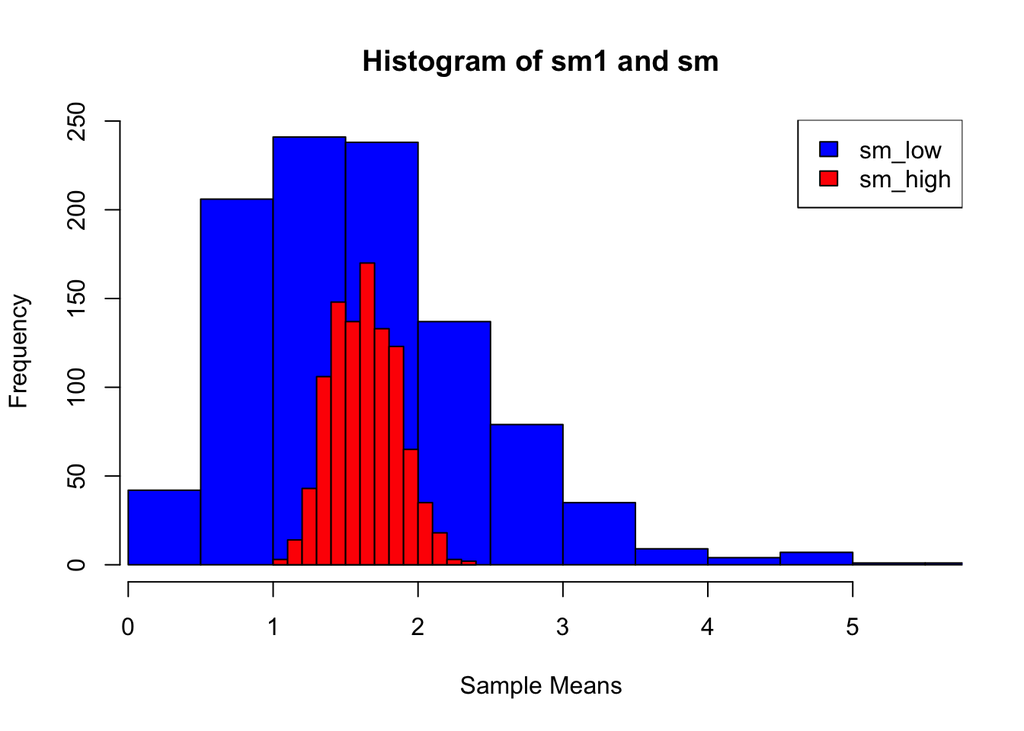

```r
# Plotting histogram of sm1 and sm together
hist(sm_low, col = "blue", main = "Histogram of sm1 and sm", xlab = "Sample Means", ylab = "Frequency", xlim = range(c(sm_high, sm_low)))
hist(sm_high, col = "red", add = TRUE)
legend("topright", legend=c("sm_low", "sm_high"), fill=c("blue", "red"))
```

[figure not shown]

```r
# Create the density plots for both samples
sm_low_d <- density(sm_low)
sm_high_d <- density(sm_high)

# Determine the plotting range
x_min <- min(min(sm_low_d$x), min(sm_high_d$x))
x_max <- max(max(sm_low_d$x), max(sm_high_d$x))
y_min <- min(min(sm_low_d$y), min(sm_high_d$y))
y_max <- max(max(sm_low_d$y), max(sm_high_d$y))

# Create a new plot with the appropriate range and margins
plot(x = c(x_min, x_max), y = c(y_min, y_max), type = "n",
     main = "Large sample Vs Small sample", xlab = "Value", ylab = "Density")

# Plot the density curves
lines(sm_low_d, col = "red")
lines(sm_high_d, col = "blue")

# Add a legend
legend("topright", legend=c("Sample Size 50", "Sample Size 4"), col=c("red", "blue"), lty=1)
```

The graphic shows that the Central Limit Theorem (CLT) curve becomes more similar to a normal distribution curve as sample size grows. On the other hand, the CLT curve diverges much further from a normal distribution curve for lower sample sizes.